# Datasource Management

Brainwave GRC

# Introduction

The new Datasource Management add-on provides an unified platform for defining and configuring the extraction and collection of data into Brainwave from various sources, directly from the web portal.

This add-on allows to: - Declare and configure datasources for extracting data to be collected in IGRC Identity Ledger - Configure the scheduling of datasources for execution on a regular basis (daily, weekly, etc) - Provide connection information for automated scripts to extract data - Perform optional validation and transformation of data to match Brainwave data model - Launch execution plans - Monitor the status of execution plans - View the history of executions plans

# Context

The new Datasource Management add-on is designed to work as part of the new distributed architecture ( portal - controller - orchestrator ) inside a Docker instance, and is pre-configured to this purpose.

## Initial setup

There are 4 configuration variables which are pre-configured for use inside Docker. Under normal use, you don’t have to modify them.

| Variable name | Variable description | value in Docker environment |
| --- | --- | --- |
| `bwdsm_sourcepath` | Base folder for raw data transfered by the controller server | `/data/sourcefiles` |
| `importfiles` | Base folder for data to be processed by collectors | `/data/importfiles` |
| `bwdsm_controller_url` | Base URL for the controller server(no ending slash) | `http://bwcontroller:4000/api` |
| `bwdsm_vault_url` | URL for the vault server ( for securly storing passwords) | `http://bwvault` |

## Understanding Datasources

This add-on introduces the concept of **Datasource** in order to normalize the configuration and processing of data to be collected inside Brainwave,

A **Datasource** is a combination of a **data collector** and a **channel** to obtain the data to be collected.  
- A **data collector** in Brainwave sense is an add-on that processes a set of data files in a specified format to feed the Brainwave Identity Ledger data model. Examples of data collectors are ActiveDirectory, CyberArk , Shared Folders, Google Drive, etc.  
- A **channel** is a way to obtain the data to be collected. It ranges from a live connection to an LDAP server, a script that is run to extract data, to a mere data file that is manually dropped in a given location.

For example, The **Microsoft Active Directory - LDAP** datasource is a combination of the **Active Directory** data collector that collects into Brainwave AD information ( accounts, groups and relationships) for some AD domain, and an LDAP channel, which is a script that connects to the domain controller through an LDAP protocol and retrieves all the data for the domain.  
This datasource is best suited when the AD domain controller to collect is within reach.

On the other hand, The **Microsoft Activity Directory - file** datasource is a combination of the same **Active Directory** data collector, and a file channel, that expects an LDIF file to be uploaded to Brainwave. This LDIF file is usually generated by running a Brainwave-provided Powershell script within reach of the target AD domain controllers. The LDIF file can then be uploaded via the brainwave controller upload API.  
This datasource is best suited when the AD Domain Controllers are out of reach from Brainwave software, typically in a DMZ network.

Note that both datasources rely of the same LDIF data files but differ from the way of obtaining it.

To ensure consistency of the collection process, all sources of data to be collected in the Identity Ledger must be declared as datasources and configured. It’s not permitted to collect data that was not declared as a datasource.

# Datasource configuration

The configure datasource page allow to add , edit and delete datasources. It is accessible from the main menu under `Datasource Management > Configure`

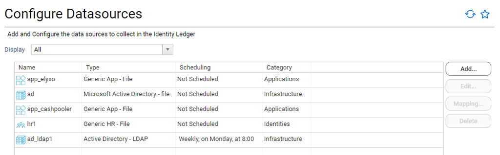

Configure datasources

The table displays the list of currently configured datasources.

Datasources are organized in 4 categories: - **Application**: datasources collecting access information on applications, such as permissions, roles and application descriptions - **Identities**: datasources collecting information about people and organisations in the enterprise, and HR information in general - **Infrastructure**: all datasources collecting data on the company infrastructure , such as accounts and groups, - **Digital workplace**: all data related to internet based productivity tools (e.g. Office 365)

To create an new datasource, click on the **Add…** button to display the datasource configuration wizard.

## Datasource type selection

The first page of the wizard allows to select the type of datasource to create.

[figure not shown]

Select datasources

**Active Directory - LDAP** : This datasource collects AD user and group information on a single Active Directory domain through an LDAP query to the domain controller.

**Active Directory - file** : This datasource collects AD user and group information on multiple Active Directory domains from a set of LDIF files.

**Note:** Only one instance of this datasource type can be created.

**Generic App - file**: This datasource collects application permissions and rights data from a csv file

**Generic HR - file**: This datasource collects people, organisation and manager data from a csv file

Click on an item title or icon to select it then click **Next** to move to the datasource options tab.

## Datasource options

This tab allows to set basic information on the datasource plus additional options specific to the selected datasource.

[figure not shown]

Datasource options

**Datasource name**: this is the unique name that identifies the datasource in the system. You should use an id that reflects the type and scope of the datasource. For example `app_elyxo` for a generic app datasource on ELYXO application. Since this name will be used to name folders where the files are located, it is preferable to use lower case letters to avoid case mismatch on Unix file systems.

**Datasource description**: give a title and short description on the purpose of the datasource

The **Options** fields are specific to the selected datasource.  
Move the mouse over the field label to display an explanation on its purpose.

Click **Next** to move the datasource Scheduling page.

## Datasource scheduling

Some datasources can automatically manage the extraction of data from the company information system. This is currently the case for **Microsoft Active Directory LDAP** and **Azure AD**. In this case, you can configure the scheduling frequency and time of data extraction.

[figure not shown]

Datasource options

**Frequency**: Set the base frequency of data extraction for the datasource, among the following: - **Daily**: the datasource will be run once a day, **at** a specified time of day . - **Weekly**: the datasource will be run once a week, on a specific **day of week**, **at** a specified time of day. - **Monthly**: the datasource will be run once a month, on a specific **day of month** and **at** a specific time of day. Use **Last** day of month to run the datasource on the last day of each month - **Not Scheduled** : scheduling is disabled entirely. You need to start the datasource manually in the controller. You can use this settings while tuning the datasource. - **Custom**: advanced scheduling using CRON syntax.

Click **Next** to view the **Summary** page, then **Finish** to close the wizard and create the datasource.

If the datasource allows column mapping ( see next section) you will be prompted whether you want to define the mapping right after the datasource creation or later.

## Datasource file definition and column mapping

Some datasources with an open file format require the extracted data files columns to be mapped to the Brainwave data model. This is the case for **Generic HR - file** and **Generic App - file**. You can even create new columns which content is computed dynamically and map them to the model.

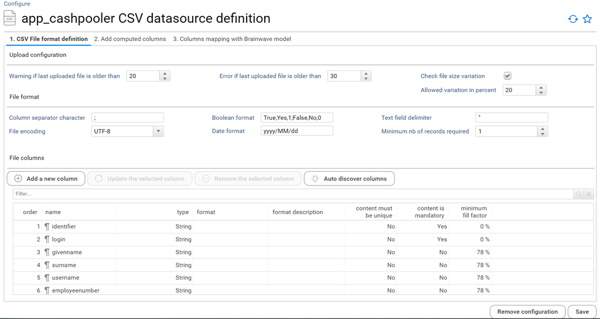

Datasource file definition and column mapping

Data mapping consists in the following steps: - **CSV File format definition** define CSV file format and columns - **Computed columns** optionally define dynamically computed columns - **Column mapping** map file columns and computed columns to the data model

### CSV file definition

CSV file definition is broken down in 3 sections:

- **Upload configuration** - What are the expectations in terms of data freshness and data quality checks at a file level
- **File format** - What is the overall CSV file format
- **File columns** - What are the expected columns in the file

**Upload configuration section**

[output not shown]

**File format**

[output not shown]

Here is the description of the date format syntax:

| Letter | Date or Time Component | Presentation | Examples |
| --- | --- | --- | --- |
| G | Era designator | Text | AD |
| y | Year | Year | 1996; 96 |
| Y | Week year | Year | 2009; 09 |
| M | Month in year | Month | July; Jul; 07 |
| w | Week in year | Number | 27 |
| W | Week in month | Number | 2 |
| D | Day in year | Number | 189 |
| d | Day in month | Number | 10 |
| F | Day of week in month | Number | 2 |
| E | Day name in week | Text | Tuesday; Tue |
| u | Day number of week (1 = Monday, …, 7 = Sunday) | Number | 1 |
| a | Am/pm marker | Text | PM |
| H | Hour in day (0-23) | Number | 0 |
| k | Hour in day (1-24) | Number | 24 |
| K | Hour in am/pm (0-11) | Number | 0 |
| h | Hour in am/pm (1-12) | Number | 12 |
| m | Minute in hour | Number | 30 |
| s | Second in minute | Number | 55 |
| S | Millisecond | Number | 978 |
| z | Time zone | General time zone | Pacific Standard Time; PST; GMT-08:00 |
| Z | Time zone | RFC 822 time zone | -0800 |
| X | Time zone | ISO 8601 time zone | -08; -0800; -08:00 |

Here are some examples:

| Date and Time Pattern | Result |
| --- | --- |
| “yyyy.MM.dd G ‘at’ HH:mm:ss z” | 2001.07.04 AD at 12:08:56 PDT |
| “EEE, MMM d, ’’yy” | Wed, Jul 4, ’01 |
| “h:mm a” | 12:08 PM |
| “hh ‘o’‘clock’ a, zzzz” | 12 o’clock PM, Pacific Daylight Time |
| “K:mm a, z” | 0:08 PM, PDT |
| “yyyyy.MMMMM.dd GGG hh:mm aaa” | 02001.July.04 AD 12:08 PM |
| “EEE, d MMM yyyy HH:mm:ss Z” | Wed, 4 Jul 2001 12:08:56 -0700 |
| “yyMMddHHmmssZ” | 010704120856-0700 |
| “yyyy-MM-dd’T’HH:mm:ss.SSSZ” | 2001-07-04T12:08:56.235-0700 |
| “yyyy-MM-dd’T’HH:mm:ss.SSSXXX” | 2001-07-04T12:08:56.235-07:00 |
| “YYYY-’W’ww-u” | 2001-W27-3 |

**File columns**

This section list all the columns in the CSV file with their expected characteristics.  
You can manually declare columns or auto-discover columns from an existing sample data file.

The validation follows a strict strategy regarding the columns of the file:

- All columns presents in the file must be declared.
- Columns must be named (first line of the file)
- Columns order can’t be changed

If one of those prerequisites is not met, the file is not considered valid.

To manually add a column, click the **Add a new column** button. The following dialog box appears:

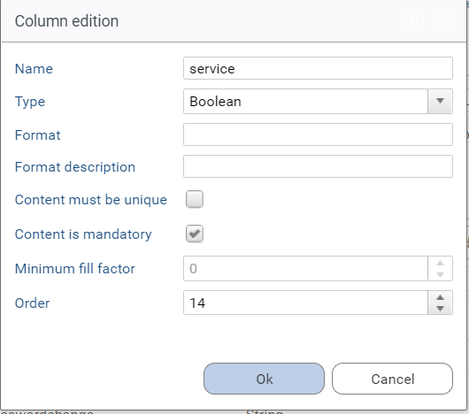

Add column

The fields in the dialog box are explained below:

[output not shown]

**Auto-discovery of columns** Declaring by hand a few dozens columns can be tedious. Fortunately, you can - and you should - create the columns automatically based on a existing typical data file.  
To automatical discover and create the file column, click the **Auto discover columns** button. The following dialog box appears:

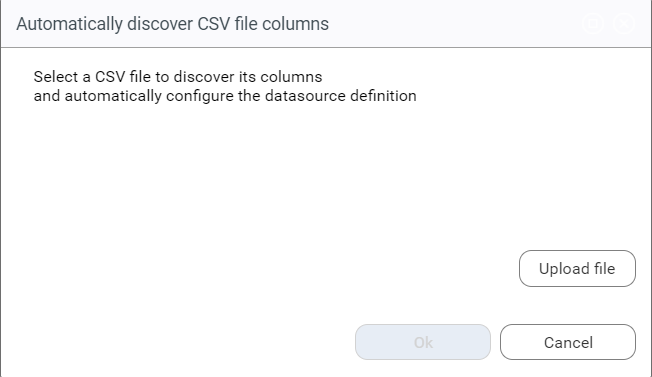

Auto discover columns

Select the typical file using the **Upload file** button. The file is analyzed then the columns are created with their characteristics, including the fill factor. This explains why file processing can take some time.

### Add computed columns

If needed you can add dynamic (computed) columns on the fly on your datasource.

This can be useful when you want to:

- add static information in your mapping
- compute dynamic information based on the current CSV line

Let’s take some examples:

- You have a CSV HR file for internal people, therefore you **know** that 100% of the identities located in this file are internal people, nevertheless this information is not located in the file itself. You can add a computed column in the form of `INTERNAL=True` in order to be able to map this information in the Brainwave datamodel.
- You have a CSV HR file with `firstname` and `lastname` and you want to map the `fullname` column of the Brainwave datamodel, therefore, you want to add a computed column in the form of `FULLNAME=CSVFIRSTNAME+' '+CSVLASTNAME` where `CSVFIRSTNAME` and `CSVLASTNAME` are the current values in the CSV file.
- You have a CSV HR file and you know that depending on the `employee number` syntax you can spot if the identity is internal or a contractor (let’s say for instance that he is an internal people if the employee number starts with `I`). You will want to create a computed column in the form of `If employeenumber starts with 'I' Then INTERNAL=True Else INTERNAL=False`.

All those use cases are covered thanks to the `Add computed columns` section.

To add a computed column, click on `Add a new computed column` and provide a name and a value in the form of a computed expression:

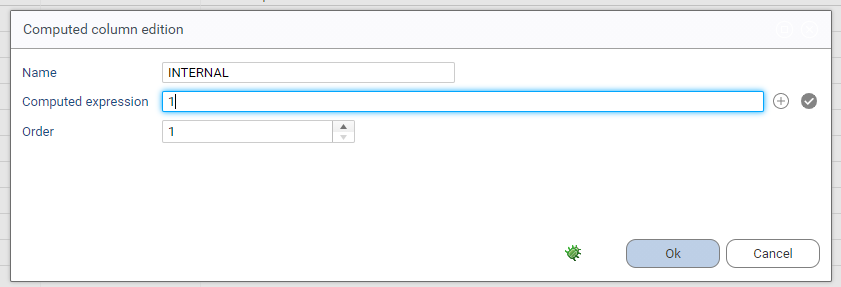

Add computed column

A computed expression is computed for each line of your CSV file. It is a simple String with escape sequences whenever you want to refer to other columns of the current line.

> **Important:** A computed expression **always** returns a String. If you want to return a Boolean value with a computed expression, you must return string character `0` for False and string character `1` for True. If you want to return a Date value with a computed expression, you must return it as a String in LDAP format `yyyyMMddHHmmss`.

The easiest way to add a reference to another column of the file is to click on the `+` icon next to the computed expression field.  
You can mix both static content and dynamic content in your computed expression.

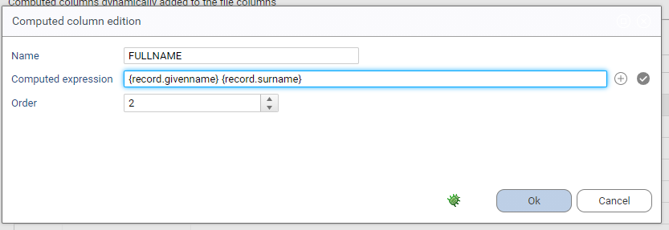

Reference another column value

As you can see, a reference to another column is in the form of `{record.COLUMNNAME}`:

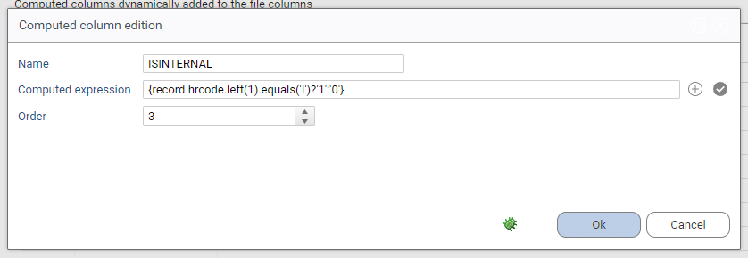

Computed column with a reference to another value

The expression within `{ }` follows a server side javascript syntax. record.COLUMNNAME is provided as String. You can add transform function to your record. If you want to return a value depending on a condition the best practice is to use ternary operator `CONDITION?VALUEIFTRUE:VALUEIFFALSE`.

> **Important:** A record is always provided in a form of a String even if the CSV column definition is a number, date, boolean, … In case of a boolean you will have `0` if False and `1` if true. In cas of a date you will have an LDAP string representation of the date `yyyyMMddHHmmss`.  
> **Important:** Computed column is an advanced feature. Don’t forget to validate your javascript expression as your configuration won’t work in case of error.

### Columns mapping with Brainwave model

Once you have declared your CSV columns and your computed columns the last thing you have to do is to map those columns to the Brainwave data model. This is done through the last tab.

All expected columns are listed in the table along with the their type and an example. In order to map a column you just have to click on the corresponding `Brainwave Attribute` in the table.  
Once the mapping is done, the CSV column name will appear in `Mapped Column`:

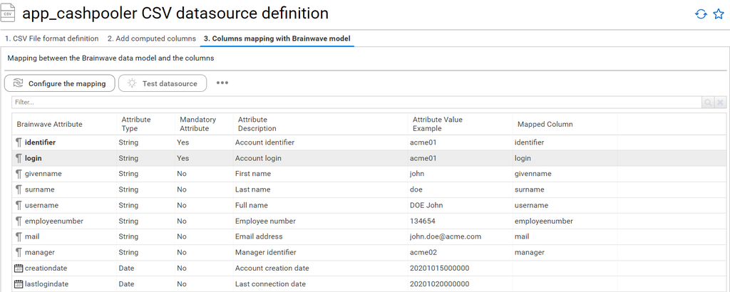

List of mapped columns

> **Important:** `Mapped Columns` background field is red In case of mandatory columns.

> **Note** If your input file complies with Brainwave pivot format, the mapping will be performed automatically. In order for this to happen both columns names and columns types must be the same.

Once your mapping is done you can test it. In order to do it click on `Test datasource` and pick your CSV file.  
The file will be uploaded, parsed and transcoded to a `pivot` format. You are **strongly encouraged** to download the transcoded file in order to check if both your mappings and your computed values are correct.

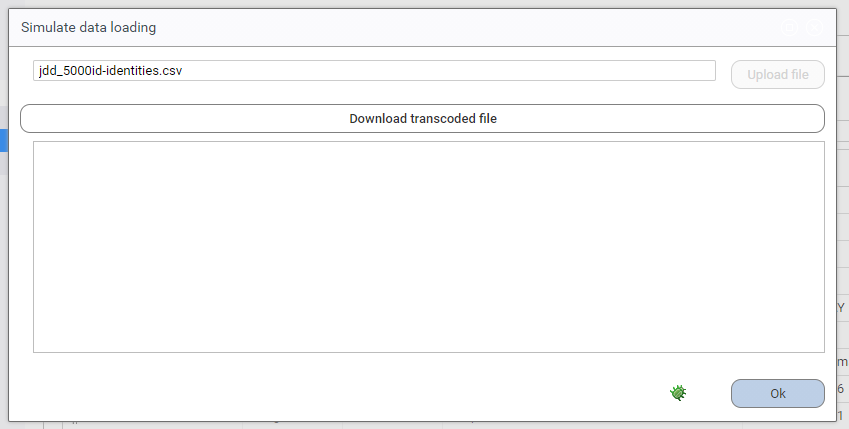

Simulate data loading

In case of configuration error, a message will appear in the dialog box:

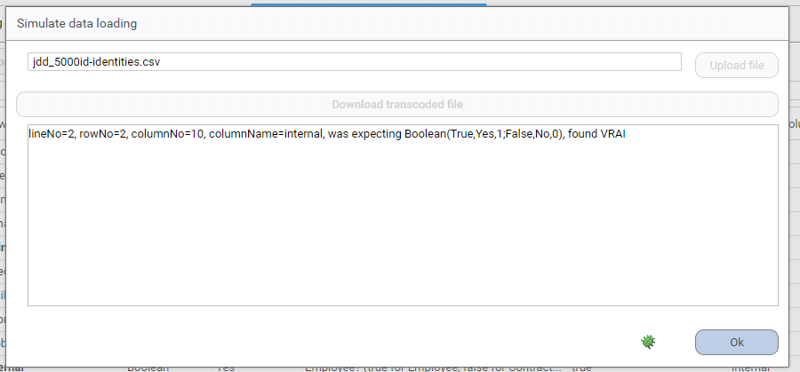

Data loading error example

# Datasource status

The status page displays the current status of configured datasource for the next execution plan. You can also manually upload single data file or a set of data files. You can launch an execution plan.

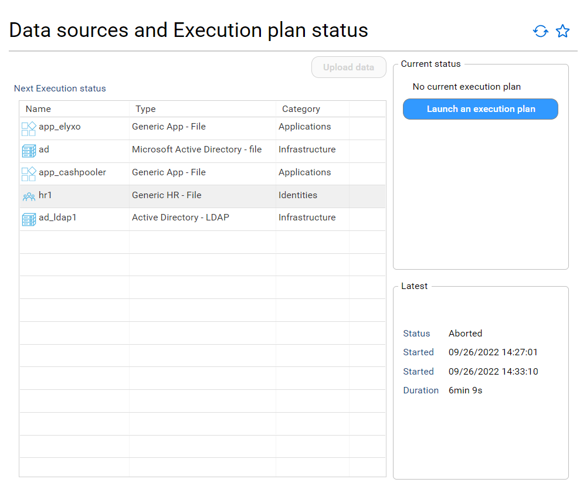

Status page

To manually upload data for a datasource, you must first select the datasource then click the **Upload data** button. The follow dialog box is displayed.

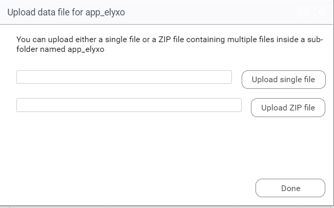

Status page upload data

**Single file upload:** Some datasources expect only one file of data. To upload manually upload this single file, select the **Upload single file** button.

**Multiple file upload:** Other datasources can process several files. For example **Active Directory - file** accepts a set of LDIF files, one file per Active Directory domain to collect.  
In this case, the files needs to be gathered in a folder than has the same name as the datasource and compressed as a zip file. You can then upload the set of files directly by clicking **Upload ZIP file** button.  
The ZIP file structure follows the controller upload API requirements. Refer to the controller API documentation for more details.

Once all the datasource files are present, you can manually launch an execution plan to collect the files in the Identity Ledger through the defined datasources.  
To launch an execution plan click the **Launch Execution Plan** button.  
The plan is then queued in the controller, and executed as soon as possible. You can following the status of execution in this same page or in the controller UI.

# Datasource history

This **Datasource History** page displays the history of execution plans and the resulting timeslots in the Identity Ledger.

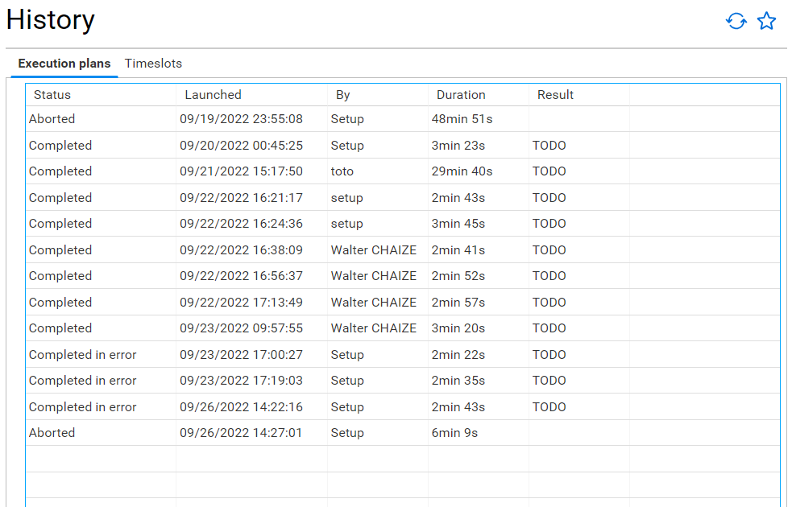

datasource History

© 2010-2020 [Brainwave GRC](https://documentation.brainwavegrc.com/)